# Philemon Rockson Notebook

Fitting Random Forest

```r
set.seed(123)
#convert quality_class to be a factor
y_quality = as.factor(train_data$quality_class)

#fit random forest
rf.mod <- randomForest(y_quality~fixed.acidity + volatile.acidity + citric.acid + residual.sugar + chlorides + free.sulfur.dioxide + total.sulfur.dioxide + density + pH + sulphates + alcohol, data = train_data, importance = TRUE)

#print(rf.mod)
#predicting using the test data
rf_pred <- predict(rf.mod, newdata = test_data)

#confusion matrix
confusion_matrix_rf <- table(Predicted = rf_pred, Actual = test_data$quality_class)
print(confusion_matrix_rf)
```

```
          Actual
Predicted  Good Not Good
  Good      236       64
  Not Good  145     1505
```

```r
#accuracy
accuracy_rf <- mean(rf_pred == test_data$quality_class)
print(paste("Test Accuracy:",round(accuracy_rf , 2)))
```

```
[1] "Test Accuracy: 0.89"
```

```r
TP <- confusion_matrix_rf["Good", "Good"]
FP <- confusion_matrix_rf["Good", "Not Good"]
FN <- confusion_matrix_rf["Not Good", "Good"]
precision_rf <- TP / (TP + FP)
recall_rf <- TP / (TP + FN)
print(paste("Precision:", round(precision_rf, 2)))
```

```
[1] "Precision: 0.79"
```

```r
print(paste("Recall:", round(recall_rf, 2)))
```

```
[1] "Recall: 0.62"
```

3. Compare classification results (Accuracy, Precision, Recall, ROC curve).

```r
#preparing the roc curve
par(mfrow=c(1,2))

pred <- prediction(glm.probs, test_data$quality_class)
perf <- performance(pred, "tpr", "fpr")


test_probabilities <- predict(rf.mod, newdata = test_data, type = "prob")[, "Good"]  # Use "Good" probability
pred_rf <- prediction(test_probabilities, test_data$quality_class == "Good")
auc_perf <- performance(pred_rf, measure = "auc")
roc_pref <- performance(pred_rf, "tpr", "fpr")
auc_rf  <- auc_perf@y.values[[1]]
#print(paste("AUC:", round(auc_perf@y.values[[1]], 2)))

auc_perf <- performance(pred, measure = "auc")
auc_value <- auc_perf@y.values[[1]]
#print(paste("AUC:", round(auc_value, 2)))

classification_compare <- data.frame(par = c("Accuracy","Precision","Recall","AUC"),logistic_regression = c(accuracy_lr,precision_lr,recall_lr,auc_value), random_forest = c(accuracy_rf,precision_rf,recall_rf,auc_rf))

classification_compare
```

| par | logistic_regression | random_forest |
| --- | --- | --- |
| Accuracy | 0.8164103 | 0.8928205 |
| Precision | 0.5595855 | 0.7866667 |
| Recall | 0.2834646 | 0.6194226 |
| AUC | 0.7994125 | 0.9186895 |

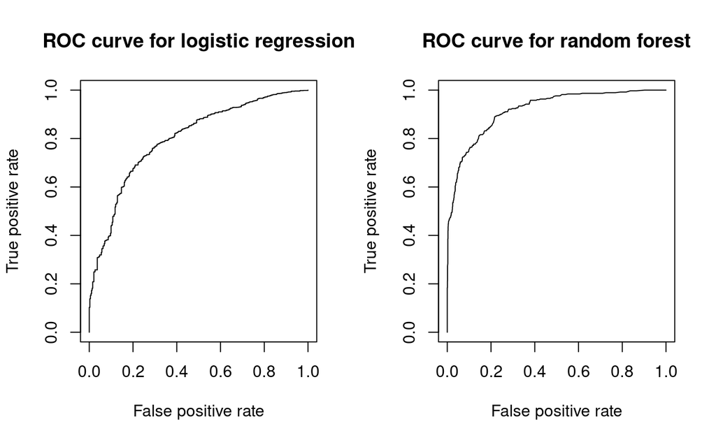

```r
plot(perf, main = "ROC curve for logistic regression")
plot(roc_pref, main = "ROC curve for random forest")
```

Accuracy:

The logistic regression model achieves an accuracy of 0.8164 (81.64%), meaning it correctly classifies approximately 81.6% of the wines in the test set, indicating a reasonable overall performance. The Random Forest model has a higher accuracy of 0.8928 (89.28%), suggesting it correctly classifies about 89.3% of the wines, demonstrating superior overall predictive power compared to logistic regression. The difference (about 7.6%) highlights Random Forest’s better generalization, likely due to its ensemble nature and ability to capture complex patterns.

Precision:

Logistic regression has a precision of 0.5596 (55.96%), indicating that only about 56% of the wines predicted as “Good” are actually “Good,” suggesting a moderate rate of false positives. Random Forest shows a higher precision of 0.7867 (78.67%), meaning about 79% of predicted “Good” wines are correct, reflecting a lower false positive rate and more reliable positive predictions. The improvement (about 23%) suggests Random Forest is better at avoiding incorrect “Good” classifications.

Recall:

Logistic regression has a recall of 0.2835 (28.35%), meaning it identifies only about 28% of the actual “Good” wines, indicating a high rate of false negatives and poor sensitivity to the “Good” class. Random Forest significantly improves recall to 0.6194 (61.94%), capturing about 62% of actual “Good” wines, showing better sensitivity and fewer missed “Good” instances. The increase (about 34%) indicates Random Forest is more effective at detecting the positive class.

AUC (Area Under the Curve):

Logistic regression has an AUC of 0.7994 (79.94%), suggesting a good ability to discriminate between “Good” and “Not Good” wines, with a 80% chance of ranking a random “Good” wine higher than a “Not Good” one. Random Forest achieves a higher AUC of 0.9187 (91.87%), indicating excellent discriminative power, with a 92% chance of correct ranking, reflecting a stronger overall classification performance. The difference (about 12%) underscores Random Forest’s superior ability to distinguish classes across thresholds.